# Storm Event Effects on Population Health and Economics (1993 - 2011)

Marcus Turnbo

November 22, 2014

This report gives an overview of analysis of storm data from the U.S. National Oceanic and Atmospheric Administration (NOAA). The data includes characteristics of major storms and weather events in the United States, including date and location, as well as estimates of any fatalities, injuries, and property damage. A simple analysis has been performed to determine events with the greatest impact in the United States.

### Data Processing

#### Data Scrubbing

A CSV file downloaded from the NOAA website is loaded into a dataframe. A copy of this data frame containing only the relevant fields is created. This dataframe will be used to scrub the downloaded data.

```r
# read storm data
# stormData <- (read.csv('./data/repdata-data-StormData.csv', header=TRUE))
stormData <- readRDS('./data/StormData.rds')
# copy select fields to new data frame for scrubbing
selectFields <- c('BGN_DATE','STATE','EVTYPE','FATALITIES','INJURIES','PROPDMG','PROPDMGEXP','CROPDMG','CROPDMGEXP','REFNUM')
cleanStormData <- stormData[,(names(stormData) %in% selectFields)]
```

902297 observations were found in the downloaded data. We are only concerned with events in the United States. We will use the **state.abb** vector to filter the data.

```r
# subset storm data in United States based on STATE value
cleanStormData <- subset(cleanStormData, STATE %in% state.abb)
```

Parse the year from the event date field and add new field to dataset. Use this to determine the range for which data is present.

```r
# create event year column
library(lubridate)
cleanStormData$event.year <- year(parse_date_time(cleanStormData$BGN_DATE, "%m/%d/%y %H%M%S"))
```

The data for the United States includes events from 1950 through 2011. We are aware that the data is more complete in recent years. We will find the earliest year for each metric we are analyzing where data is available.

```r
# find earliest years where data exists
earliestFatalityYear <- min(cleanStormData[cleanStormData$FATALITIES > 0, c('event.year')])
earliestInjuryYear <- min(cleanStormData[cleanStormData$INJURIES > 0, c('event.year')])
earliestPropertyDamageYear <- min(cleanStormData[cleanStormData$PROPDMG > 0, c('event.year')])
earliestCropDamageYear <- min(cleanStormData[cleanStormData$CROPDMG > 0, c('event.year')])
minYear <- max(earliestFatalityYear, earliestInjuryYear, earliestPropertyDamageYear, earliestCropDamageYear)
```

Since the data is not complete prior to 1993, we will limit our analysis to years since 1993.

```r
# filter for minimum year
cleanStormData <- subset(cleanStormData, event.year >= minYear)
```

According to the field definitions from the NOAA, exponents of the property and crop damage values are stored in a separate fields, PROPDMGEXP and CROPDMGEXP. The exponent values are as follows:

```r
cleanStormData$PROPDMGEXP = toupper(cleanStormData$PROPDMGEXP)
cleanStormData$CROPDMGEXP = toupper(cleanStormData$CROPDMGEXP)
propertyExponents = unique(cleanStormData$PROPDMGEXP)
cropExponents = unique(cleanStormData$CROPDMGEXP)
```

Property Damage Exponents: , B, K, M, +, 0, 5, 6, ?, 4, 2, 3, H, 7, -, 1, 8 Crop Damage Exponents: , M, K, B, ?, 0, 2

I will assume the following exponent definitions and filter the data to only use values containing them:  
K = thousands  
M = millions  
B = billions

```r
# filter storm data based on exponents
cleanStormData = subset(cleanStormData, PROPDMGEXP %in% c('K','M','B','') & CROPDMGEXP %in% c('K','M','B',''))
```

Add fields with the property and crop damage values multiplied by the exponents. Create a function to apply the exponent to the values present.

```r
multiplyExponent <- function(x, exp) {
  if (!(exp %in% c('K','M','B'))) {
    x
  } else {
    switch(exp,
      'K' = x * 1000,
      'M' = x * 1000000,
      'B' = x * 1000000000
    )
  }
}

cleanStormData$Property.Damage = mapply(multiplyExponent, cleanStormData[,"PROPDMG"], cleanStormData[,"PROPDMGEXP"])
cleanStormData$Crop.Damage = mapply(multiplyExponent, cleanStormData[,"CROPDMG"], cleanStormData[,"CROPDMGEXP"])
cleanStormData$Total.Damage = cleanStormData$Property.Damage + cleanStormData$Crop.Damage
```

### Results

#### Population Health

```r
library(data.table)
meanHealthImpact = data.table(aggregate(cbind(FATALITIES, INJURIES) ~ EVTYPE, data=cleanStormData, FUN=mean))
topFatalities =  head(meanHealthImpact[order(-meanHealthImpact$FATALITIES)], 5)
setnames(topFatalities, c("EVTYPE", "FATALITIES", "INJURIES"), c("Event.Type", "Fatalities", "Injuries"))
topFatalities
```

```
##                    Event.Type Fatalities  Injuries
## 1: TORNADOES, TSTM WIND, HAIL  25.000000  0.000000
## 2:              COLD AND SNOW  14.000000  0.000000
## 3:      TROPICAL STORM GORDON   8.000000 43.000000
## 4:      RECORD/EXCESSIVE HEAT   5.666667  0.000000
## 5:               EXTREME HEAT   4.571429  7.380952
```

```r
topInjuries =  head(meanHealthImpact[order(-meanHealthImpact$INJURIES)], 5)
setnames(topInjuries, c("EVTYPE", "FATALITIES", "INJURIES"), c("Event.Type", "Fatalities", "Injuries"))
topInjuries
```

```
##               Event.Type Fatalities Injuries
## 1:             Heat Wave       0.00     70.0
## 2: TROPICAL STORM GORDON       8.00     43.0
## 3:            WILD FIRES       0.75     37.5
## 4:         THUNDERSTORMW       0.00     27.0
## 5:       SNOW/HIGH WINDS       0.00     18.0
```

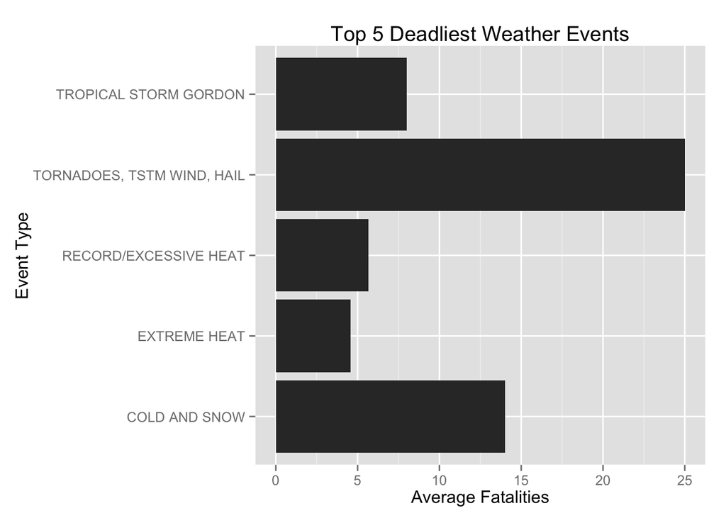

```r
library(ggplot2)
fig1 <- ggplot(topFatalities, aes(x=Event.Type, y=Fatalities))
fig1 <- fig1 + geom_bar(stat="identity")
fig1 <- fig1 + coord_flip()
fig1 <- fig1 + labs(title="Top 5 Deadliest Weather Events") + xlab("Event Type") + ylab("Average Fatalities")
fig1
```

[figure not shown]

```r
fig2 <- ggplot(topInjuries, aes(x=Event.Type, y=Injuries))
fig2 <- fig2 + geom_bar(stat="identity")
fig2 <- fig2 + coord_flip()
fig2 <- fig2 + labs(title="Top 5 Injury Causing Events") + xlab("Event Type") + ylab("Average Fatalities")
fig2
```

#### Economic Impact

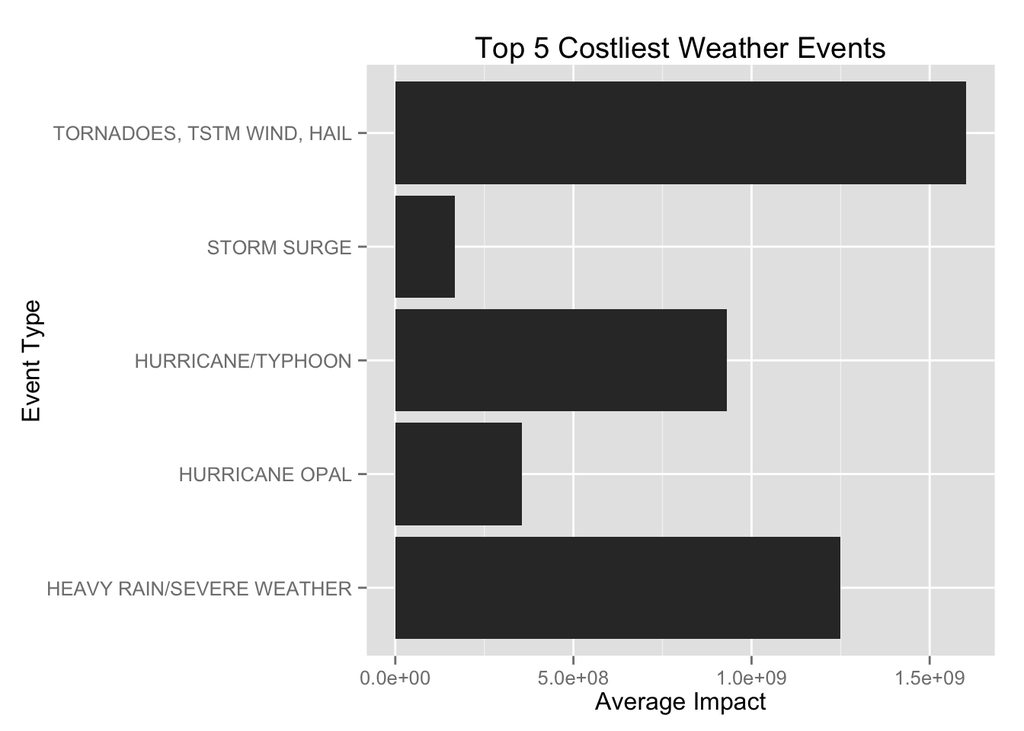

```r
meanEconomicImpact = data.table(aggregate(cbind(Property.Damage, Crop.Damage, Total.Damage) ~ EVTYPE, data=cleanStormData, FUN=mean))
topEconomicImpact =  head(meanEconomicImpact[order(-meanEconomicImpact$Property.Damage , -meanEconomicImpact$Crop.Damage)], 5)
setnames(topEconomicImpact, c("EVTYPE"), c("Event.Type"))

library(ggplot2)
fig3 <- ggplot(topEconomicImpact, aes(x=Event.Type, y=Total.Damage))
fig3 <- fig3 + geom_bar(stat="identity", position=position_dodge())
fig3 <- fig3 + coord_flip()
fig3 <- fig3 + labs(title="Top 5 Costliest Weather Events") + xlab("Event Type") + ylab("Average Impact")
fig3
```

Based on the summary data, we are able to make the following conclusions based on averages per event type: **Tornadoes** are the deadliest storm events.  
**Heat Waves** caused the most injuries. **Tornados** have the greatest economic impact.